# NYS Tobacco and Vapor Vendors - Data Cleaning and Analysis

```
        #### Created by: Peter A. Blackwell      Last Updated: March 2024 (cleaned up March 2026)
```

The purpose of this analysis is purely a freelance data cleaning and analysis exercise using Python and an available government dataset.

In this case, the source of this dataset is a New York State government health site - in this case, 'Active Retail Tobacco and Vapor Product Vendors'

https://health.data.ny.gov/Health/Active-Retail-Tobacco-and-Vapor-Product-Vendors/9ma3-vsuk/about_data

Note that there is only one date field on the dataset (CREATION DATE) with the same value for all fields - which precludes date-themed graphs, but we can do other types of analyses.

```python
# start by importing libraries
import pandas as pd
import seaborn as sns
import matplotlib.pyplot as plt
import re
import numpy as np
import plotly.express as px
```

I have downloaded the latest version of the dataset and loaded from a local drive for faster runtime

```python
df = pd.read_csv(r"C:\Users\peter\Documents\Excel test docs\Active_Retail_Tobacco_and_Vapor_Product_Vendors.csv")
df
```

|  | LOCAL HEALTH UNIT | OPERATION NAME | ADDRESS | CITY | STATE | ZIP | MUNICIPALITY | COUNTY | VENDOR TYPE | CREATION DATE | LOCATION |
| --- | --- | --- | --- | --- | --- | --- | --- | --- | --- | --- | --- |
| 0 | CLINTON | GRAND UNION | 2 GORMAN WAY | PERU | NY | 12972.0 | PERU | CLINTON | GROCERY SUPERMARKET | 07/10/2023 | 2 GORMAN WAY\nPERU, NY 12972\n(44.577028232, -... |
| 1 | DUTCHESS | CHESTNUT MARTS | 3997 ROUTE 22 | WASSAIC | NY | 12592.0 | AMENIA | DUTCHESS | CONVENIENCE/GAS | 07/10/2023 | 3997 ROUTE 22\nWASSAIC, NY 12592\n(41.79081480... |
| 2 | NYC | 2918 GAS CORP | 2918 BOSTON ROAD | BRONX | NY | 10469.0 | BRONX | NEW YORK CITY | OTHER | 07/10/2023 | 2918 BOSTON ROAD\nBRONX, NY 10469\n(40.8680588... |
| 3 | NYC | MAHANT 385 INC | 385 CANAL STREET | NEW YORK | NY | 10013.0 | MANHATTAN | NEW YORK CITY | TOBACCO RETAIL | 07/10/2023 | 385 CANAL STREET\nNEW YORK, NY 10013\n(40.7216... |
| 4 | NYC | SHISHA KING CORP | 656 SUTTER AVENUE | BROOKLYN | NY | 11207.0 | BROOKLYN | NEW YORK CITY | GROCERY SUPERMARKET | 07/10/2023 | 656 SUTTER AVENUE\nBROOKLYN, NY 11207\n(40.669... |
| ... | ... | ... | ... | ... | ... | ... | ... | ... | ... | ... | ... |
| 16754 | CHAUTAUQUA | MATT'S NEWS | 93 EAST THIRD STREET | DUNKIRK | NY | 14048.0 | DUNKIRK | CHAUTAUQUA | CONVENIENCE STORE | 07/10/2023 | 93 EAST THIRD STREET\nDUNKIRK, NY 14048\n(42.4... |
| 16755 | NYC | EASTSIDE CONVENIENCE CORPORATION | 1726 1ST AVENUE | NEW YORK | NY | 10128.0 | MANHATTAN | NEW YORK CITY | CONVENIENCE STORE | 07/10/2023 | 1726 1ST AVENUE\nNEW YORK, NY 10128\n(40.7790... |
| 16756 | NYC | DOPEBOYS EXOTIC INC | 1437 FLATBUSH AVENUE | BROOKLYN | NY | 11210.0 | BROOKLYN | NEW YORK CITY | GROCERY SUPERMARKET | 07/10/2023 | 1437 FLATBUSH AVENUE\nBROOKLYN, NY 11210\n(40.... |
| 16757 | GLENS FALLS DO | STEWART'S SHOP #215 | 107 BROADWAY | FORT EDWARD | NY | 12828.0 | FORT EDWARD | WASHINGTON | CONVENIENCE STORE | 07/10/2023 | 107 BROADWAY\nFORT EDWARD, NY 12828\n(43.26720... |
| 16758 | NYC | A & S ROCKAWAY DELI GROCERY CORP. | 123-36 ROCKAWAY BOULEVARD | SOUTH OZONE PARK | NY | 11420.0 | QUEENS | NEW YORK CITY | GROCERY SUPERMARKET | 07/10/2023 | 123-36 ROCKAWAY BOULEVARD\nSOUTH OZONE PARK, N... |

16759 rows × 11 columns

Check the datatypes on the imported dataset

Note that the ZIP is 'not' an object; it is a float type (not integer)

```python
df.dtypes
```

```
LOCAL HEALTH UNIT     object
OPERATION NAME        object
ADDRESS               object
CITY                  object
STATE                 object
ZIP                  float64
MUNICIPALITY          object
COUNTY                object
VENDOR TYPE           object
CREATION DATE         object
LOCATION              object
dtype: object
```

See how many null ZIP codes we have in the dataset

These will need to be cleaned up - we can use the latitude and longitude embedded in the LOCATION field to do so

```python
df['ZIP'].isna().sum()
```

```
80
```

General cleanup query - see how many columns are missing data in general.

The results show that only one row is missing data in the 'LOCATION' column that we will use for determining zip code as needed for the missing zip codes

```python
df.notnull().sum()
```

```
LOCAL HEALTH UNIT    16759
OPERATION NAME       16759
ADDRESS              16759
CITY                 16679
STATE                16759
ZIP                  16679
MUNICIPALITY         16757
COUNTY               16759
VENDOR TYPE          16759
CREATION DATE        16759
LOCATION             16758
dtype: int64
```

Temporarily fill in the null ZIP codes with a -1 so we can do loops, etc. without NaN headaches

```python
df["ZIP"].fillna(-1, inplace = True)
```

Change the type of the ZIP to Integer, to make mapping easier later on

```python
df['ZIP'] = df['ZIP'].astype('int64')
```

Remove the linefeed (\n) characters from the dataset - mainly the LOCATION column for cleaning

```python
df = df.replace(r'\n',' ', regex=True)
```

Change the LOCATION to a str datatype to make extracting data easier

```python
df['LOCATION'].apply(str)
```

```
0        2 GORMAN WAY PERU, NY 12972 (44.577028232, -73...
1        3997 ROUTE 22 WASSAIC, NY 12592 (41.790814801,...
2        2918 BOSTON ROAD BRONX, NY 10469 (40.868058834...
3        385 CANAL STREET NEW YORK, NY 10013 (40.721667...
4        656 SUTTER AVENUE BROOKLYN, NY 11207 (40.66938...
                               ...
16754    93 EAST THIRD STREET DUNKIRK, NY 14048 (42.485...
16755    1726 1ST  AVENUE NEW YORK, NY 10128 (40.779000...
16756    1437 FLATBUSH AVENUE BROOKLYN, NY 11210 (40.63...
16757    107 BROADWAY FORT EDWARD, NY 12828 (43.2672095...
16758    123-36 ROCKAWAY BOULEVARD SOUTH OZONE PARK, NY...
Name: LOCATION, Length: 16759, dtype: object
```

We will get the missing Zip codes using the embedded Latitude and Longitude in the LOCATION column.

That data first needs to be extracted from the LOCATION column so we can use. We will extract longitude information within the parentheses of 'LOCATION' and create a new column 'LAT_LONG'

Then we will split out the Latitutde and Longitude of 'LAT_LONG' into independent columns

```python
# Extract longitude information within parentheses of 'LOCATION' and create a new column 'LAT_LONG'
#
df['LAT_LONG'] = df['LOCATION'].str.extract(r'^(?:.*\()?([^()]*)\)?$')

# Split out the Latitutde and Longitude of 'LAT_LONG' into independent columns
#
df[['LATITUDE', 'LONGITUDE']] = df.LAT_LONG.str.split(",", expand = True)
df
```

|  | LOCAL HEALTH UNIT | OPERATION NAME | ADDRESS | CITY | STATE | ZIP | MUNICIPALITY | COUNTY | VENDOR TYPE | CREATION DATE | LOCATION | LAT_LONG | LATITUDE | LONGITUDE |
| --- | --- | --- | --- | --- | --- | --- | --- | --- | --- | --- | --- | --- | --- | --- |
| 0 | CLINTON | GRAND UNION | 2 GORMAN WAY | PERU | NY | 12972 | PERU | CLINTON | GROCERY SUPERMARKET | 07/10/2023 | 2 GORMAN WAY PERU, NY 12972 (44.577028232, -73... | 44.577028232, -73.525724408 | 44.577028232 | -73.525724408 |
| 1 | DUTCHESS | CHESTNUT MARTS | 3997 ROUTE 22 | WASSAIC | NY | 12592 | AMENIA | DUTCHESS | CONVENIENCE/GAS | 07/10/2023 | 3997 ROUTE 22 WASSAIC, NY 12592 (41.790814801,... | 41.790814801, -73.553360632 | 41.790814801 | -73.553360632 |
| 2 | NYC | 2918 GAS CORP | 2918 BOSTON ROAD | BRONX | NY | 10469 | BRONX | NEW YORK CITY | OTHER | 07/10/2023 | 2918 BOSTON ROAD BRONX, NY 10469 (40.868058834... | 40.868058834, -73.858776062 | 40.868058834 | -73.858776062 |
| 3 | NYC | MAHANT 385 INC | 385 CANAL STREET | NEW YORK | NY | 10013 | MANHATTAN | NEW YORK CITY | TOBACCO RETAIL | 07/10/2023 | 385 CANAL STREET NEW YORK, NY 10013 (40.721667... | 40.721667889, -74.004767693 | 40.721667889 | -74.004767693 |
| 4 | NYC | SHISHA KING CORP | 656 SUTTER AVENUE | BROOKLYN | NY | 11207 | BROOKLYN | NEW YORK CITY | GROCERY SUPERMARKET | 07/10/2023 | 656 SUTTER AVENUE BROOKLYN, NY 11207 (40.66938... | 40.669383086, -73.894472157 | 40.669383086 | -73.894472157 |
| ... | ... | ... | ... | ... | ... | ... | ... | ... | ... | ... | ... | ... | ... | ... |
| 16754 | CHAUTAUQUA | MATT'S NEWS | 93 EAST THIRD STREET | DUNKIRK | NY | 14048 | DUNKIRK | CHAUTAUQUA | CONVENIENCE STORE | 07/10/2023 | 93 EAST THIRD STREET DUNKIRK, NY 14048 (42.485... | 42.485506391, -79.329351149 | 42.485506391 | -79.329351149 |
| 16755 | NYC | EASTSIDE CONVENIENCE CORPORATION | 1726 1ST AVENUE | NEW YORK | NY | 10128 | MANHATTAN | NEW YORK CITY | CONVENIENCE STORE | 07/10/2023 | 1726 1ST AVENUE NEW YORK, NY 10128 (40.779000... | 40.779000651, -73.947582326 | 40.779000651 | -73.947582326 |
| 16756 | NYC | DOPEBOYS EXOTIC INC | 1437 FLATBUSH AVENUE | BROOKLYN | NY | 11210 | BROOKLYN | NEW YORK CITY | GROCERY SUPERMARKET | 07/10/2023 | 1437 FLATBUSH AVENUE BROOKLYN, NY 11210 (40.63... | 40.635653511, -73.950397388 | 40.635653511 | -73.950397388 |
| 16757 | GLENS FALLS DO | STEWART'S SHOP #215 | 107 BROADWAY | FORT EDWARD | NY | 12828 | FORT EDWARD | WASHINGTON | CONVENIENCE STORE | 07/10/2023 | 107 BROADWAY FORT EDWARD, NY 12828 (43.2672095... | 43.26720959700003, -73.58553800399994 | 43.26720959700003 | -73.58553800399994 |
| 16758 | NYC | A & S ROCKAWAY DELI GROCERY CORP. | 123-36 ROCKAWAY BOULEVARD | SOUTH OZONE PARK | NY | 11420 | QUEENS | NEW YORK CITY | GROCERY SUPERMARKET | 07/10/2023 | 123-36 ROCKAWAY BOULEVARD SOUTH OZONE PARK, NY... | 40.67530578, -73.813723332 | 40.67530578 | -73.813723332 |

16759 rows × 14 columns

Data © OpenStreetMap contributors, ODbL 1.0. https://osm.org/copyright

Custom function to get a Zip code using OpenStreetMap

Input - the ZIP, LONGITUDE, and LATITUDE fields from the dataframe

Function logic: If the ZIP is > 10000 (valid New York State ZIP), then assume we are good - return the ZIP value else - use the geolocator reverse package to search for the ZIP based off the LONGITUDE, and LATITUDE - return that value, or an error if any

```python
import geopy
from geopy.geocoders import Nominatim

from geopy.exc import GeocoderTimedOut, GeocoderServiceError

# Initialize geocoder with a descriptive user_agent
geolocator = Nominatim(
    user_agent="NYSTVPANLSYS",
    timeout=10  # Timeout in seconds
)

def get_zipcode(zip_field, lat_field, lon_field):
    if (zip_field > 10000):
        return (zip_field)
    else:
#        print(lat_field , ' ', lon_field)
        try:
            location = geolocator.reverse("{}, {}".format(lat_field, lon_field))
            return location.raw['address']['postcode']
        except (AttributeError, KeyError, ValueError):
            print(repr(e), lat_field, lon_field)
        return None
```

Create a new column 'TEMPZIP' using the new the custom function above -

```python
from geopy.extra.rate_limiter import RateLimiter

# 1. Create a "Rate Limited" version of your geolocator
# min_delay_seconds=1 ensures you stay within the 1 req/sec policy
geocode_with_delay = RateLimiter(geolocator.reverse, min_delay_seconds=1)

# 2. Modify your function slightly to use the rate limiter
def get_zipcode_safe(row):
    # Skip if ZIP is already valid
    if row['ZIP'] > 10000:
        return row['ZIP']

    try:
        # Construct coordinates string
        query = f"{row['LATITUDE']}, {row['LONGITUDE']}"
        location = geocode_with_delay(query)

        if location:
            return location.raw['address'].get('postcode')
    except Exception as e:
        print(f"Error at {row['LATITUDE']}: {e}")

    return None

# 3. Apply the function row-by-row (axis=1)
# Note: This will take 1 second per missing ZIP code!
df['TEMPZIP'] = df.apply(get_zipcode_safe, axis=1)
df
```

|  | LOCAL HEALTH UNIT | OPERATION NAME | ADDRESS | CITY | STATE | ZIP | MUNICIPALITY | COUNTY | VENDOR TYPE | CREATION DATE | LOCATION | LAT_LONG | LATITUDE | LONGITUDE | TEMPZIP |
| --- | --- | --- | --- | --- | --- | --- | --- | --- | --- | --- | --- | --- | --- | --- | --- |
| 0 | CLINTON | GRAND UNION | 2 GORMAN WAY | PERU | NY | 12972 | PERU | CLINTON | GROCERY SUPERMARKET | 07/10/2023 | 2 GORMAN WAY PERU, NY 12972 (44.577028232, -73... | 44.577028232, -73.525724408 | 44.577028232 | -73.525724408 | 12972 |
| 1 | DUTCHESS | CHESTNUT MARTS | 3997 ROUTE 22 | WASSAIC | NY | 12592 | AMENIA | DUTCHESS | CONVENIENCE/GAS | 07/10/2023 | 3997 ROUTE 22 WASSAIC, NY 12592 (41.790814801,... | 41.790814801, -73.553360632 | 41.790814801 | -73.553360632 | 12592 |
| 2 | NYC | 2918 GAS CORP | 2918 BOSTON ROAD | BRONX | NY | 10469 | BRONX | NEW YORK CITY | OTHER | 07/10/2023 | 2918 BOSTON ROAD BRONX, NY 10469 (40.868058834... | 40.868058834, -73.858776062 | 40.868058834 | -73.858776062 | 10469 |
| 3 | NYC | MAHANT 385 INC | 385 CANAL STREET | NEW YORK | NY | 10013 | MANHATTAN | NEW YORK CITY | TOBACCO RETAIL | 07/10/2023 | 385 CANAL STREET NEW YORK, NY 10013 (40.721667... | 40.721667889, -74.004767693 | 40.721667889 | -74.004767693 | 10013 |
| 4 | NYC | SHISHA KING CORP | 656 SUTTER AVENUE | BROOKLYN | NY | 11207 | BROOKLYN | NEW YORK CITY | GROCERY SUPERMARKET | 07/10/2023 | 656 SUTTER AVENUE BROOKLYN, NY 11207 (40.66938... | 40.669383086, -73.894472157 | 40.669383086 | -73.894472157 | 11207 |
| ... | ... | ... | ... | ... | ... | ... | ... | ... | ... | ... | ... | ... | ... | ... | ... |
| 16754 | CHAUTAUQUA | MATT'S NEWS | 93 EAST THIRD STREET | DUNKIRK | NY | 14048 | DUNKIRK | CHAUTAUQUA | CONVENIENCE STORE | 07/10/2023 | 93 EAST THIRD STREET DUNKIRK, NY 14048 (42.485... | 42.485506391, -79.329351149 | 42.485506391 | -79.329351149 | 14048 |
| 16755 | NYC | EASTSIDE CONVENIENCE CORPORATION | 1726 1ST AVENUE | NEW YORK | NY | 10128 | MANHATTAN | NEW YORK CITY | CONVENIENCE STORE | 07/10/2023 | 1726 1ST AVENUE NEW YORK, NY 10128 (40.779000... | 40.779000651, -73.947582326 | 40.779000651 | -73.947582326 | 10128 |
| 16756 | NYC | DOPEBOYS EXOTIC INC | 1437 FLATBUSH AVENUE | BROOKLYN | NY | 11210 | BROOKLYN | NEW YORK CITY | GROCERY SUPERMARKET | 07/10/2023 | 1437 FLATBUSH AVENUE BROOKLYN, NY 11210 (40.63... | 40.635653511, -73.950397388 | 40.635653511 | -73.950397388 | 11210 |
| 16757 | GLENS FALLS DO | STEWART'S SHOP #215 | 107 BROADWAY | FORT EDWARD | NY | 12828 | FORT EDWARD | WASHINGTON | CONVENIENCE STORE | 07/10/2023 | 107 BROADWAY FORT EDWARD, NY 12828 (43.2672095... | 43.26720959700003, -73.58553800399994 | 43.26720959700003 | -73.58553800399994 | 12828 |
| 16758 | NYC | A & S ROCKAWAY DELI GROCERY CORP. | 123-36 ROCKAWAY BOULEVARD | SOUTH OZONE PARK | NY | 11420 | QUEENS | NEW YORK CITY | GROCERY SUPERMARKET | 07/10/2023 | 123-36 ROCKAWAY BOULEVARD SOUTH OZONE PARK, NY... | 40.67530578, -73.813723332 | 40.67530578 | -73.813723332 | 11420 |

16759 rows × 15 columns

### DATA CHECKS

Data check #1 - query the rows with a NULL in latitude / longitude

- results are just one row, with a legit ZIP code, so we are good here

```python
df_missing_location = df.loc[df['LAT_LONG'].isnull()]
df_missing_location
```

|  | LOCAL HEALTH UNIT | OPERATION NAME | ADDRESS | CITY | STATE | ZIP | MUNICIPALITY | COUNTY | VENDOR TYPE | CREATION DATE | LOCATION | LAT_LONG | LATITUDE | LONGITUDE | TEMPZIP |
| --- | --- | --- | --- | --- | --- | --- | --- | --- | --- | --- | --- | --- | --- | --- | --- |
| 132 | ONONDAGA | MIRABITO HOLDINGS, INC. | 2052 RT. 5W TURNPIKE | CAMILLUS | NY | 13031 | CAMILLUS | ONONDAGA | CONVENIENCE/GAS | 07/10/2023 | NaN | NaN | NaN | NaN | 13031 |

Data check #2 - query the rows with a ZIP < 10000, see the TEMPZIP value

- results are we have found a value for these records, so the function worked

```python
for index, row in df.iterrows():
    if row['ZIP'] < 10000:
        print(row['ZIP'], row['LATITUDE'], row['LONGITUDE'], row['TEMPZIP'])
```

```
117 40.760975695  -73.029896708 11772
-1 40.995954451  -72.339820222 11963
117 40.835619901  -73.186186223 11788
-1 40.72025  -73.24917 11706
-1 40.877578874  -72.526480515 11946
-1 40.897992454  -73.046029263 11776
-1 41.000111695  -72.293619594 11963
1350 43.107406379  -75.253902844 13502
-1 40.771373874  -73.260079098 11706
-1 40.723916921  -73.243838825 11706
135 43.086482814  -75.218768434 13501
-1 43.341204619  -75.74985395 13316
-1 40.817329125  -73.266336775 11788
-1 40.703704506  -73.9908508 11201
-1 40.781579165  -72.865285729 11967
1729 40.763946083  -73.320935067 11729
1117 40.681450344  -73.846851799 11417
-1 40.865796097  -73.036426032 11784
-1 40.752818059  -73.00983939 11772
-1 40.919815326  -73.05283914 11776
-1 40.782540371  -73.218559256 11717
-1 40.889879107  -73.015642852 11727
1001 40.696119052  -73.920090857 11221
-1 40.706885732  -73.301061743 11795
-1 40.892200852  -73.014597377 11727
-1 40.69749381  -73.284096938 11795
-1 40.810585995  -72.953654103 11763
1172 40.782661112  -73.200577224 11722
-1 40.657089823  -73.626532988 11570
1045 40.833909116  -73.927310358 10452
100 40.836862061  -73.943510649 10032
-1 40.791453477  -73.199812543 11722
1143 40.712764757  -73.782720265 11432
-1 41.114799348  -72.361514434 11944
1046 40.826253044  -73.821990906 10465
117 40.807506738  -73.122983333 11779
-1 40.805813988  -73.268744373 11717
1045 40.838551852  -73.906389463 10456
1 40.813027865  -73.130102649 11779
-1 40.50705588  -74.246458111 10307
```

[output cut: 88 more lines]

```
112 40.610472933  -73.984510477 11204
1137 40.737420115  -73.883554488 11373
-1 41.445786519  -74.598338888 12729
-1 40.656809978  -73.587337424 11520
1002 40.719123646  -73.990841831 10002
-1 40.935928403  -73.015870169 11766
-1 40.804054873  -72.763401965 11940
-1 40.74521978  -73.088456529 11782
1120 40.684083603  -73.871101567 11208
137 42.323682876  -75.77606121 13778
1143 40.64342  -73.78193 11430
11 40.805491612  -73.180620606 11749
117 40.746514281  -73.056106154 11705
11 40.695698825  -73.838859235 11418
1122 40.692104162  -73.937009477 11221
```

#### Further Cleanup of the df dataset -

1. Drop the old ZIP column; replace with the newly created TEMPZIP column
2. Drop the LAT_LONG column since we split into LATITUDE and LONGITUDE
3. Rename county from NEW YORK CITY to NEW YORK (needed for merge later on)
4. Put a space in the "ST.< >LAWRENCE" county (for same reason)

```python
df = df.drop('ZIP', axis=1)
df = df.drop('LAT_LONG', axis=1)
df.rename(columns={"TEMPZIP": "ZIP"}, inplace=True)
df['COUNTY'] = df['COUNTY'].apply(lambda x: 'NEW YORK' if x == 'NEW YORK CITY' else x)
df['COUNTY'] = df['COUNTY'].apply(lambda x: 'ST. LAWRENCE' if x == 'ST.LAWRENCE' else x)
df
```

|  | LOCAL HEALTH UNIT | OPERATION NAME | ADDRESS | CITY | STATE | MUNICIPALITY | COUNTY | VENDOR TYPE | CREATION DATE | LOCATION | LATITUDE | LONGITUDE | ZIP |
| --- | --- | --- | --- | --- | --- | --- | --- | --- | --- | --- | --- | --- | --- |
| 0 | CLINTON | GRAND UNION | 2 GORMAN WAY | PERU | NY | PERU | CLINTON | GROCERY SUPERMARKET | 07/10/2023 | 2 GORMAN WAY PERU, NY 12972 (44.577028232, -73... | 44.577028232 | -73.525724408 | 12972 |
| 1 | DUTCHESS | CHESTNUT MARTS | 3997 ROUTE 22 | WASSAIC | NY | AMENIA | DUTCHESS | CONVENIENCE/GAS | 07/10/2023 | 3997 ROUTE 22 WASSAIC, NY 12592 (41.790814801,... | 41.790814801 | -73.553360632 | 12592 |
| 2 | NYC | 2918 GAS CORP | 2918 BOSTON ROAD | BRONX | NY | BRONX | NEW YORK | OTHER | 07/10/2023 | 2918 BOSTON ROAD BRONX, NY 10469 (40.868058834... | 40.868058834 | -73.858776062 | 10469 |
| 3 | NYC | MAHANT 385 INC | 385 CANAL STREET | NEW YORK | NY | MANHATTAN | NEW YORK | TOBACCO RETAIL | 07/10/2023 | 385 CANAL STREET NEW YORK, NY 10013 (40.721667... | 40.721667889 | -74.004767693 | 10013 |
| 4 | NYC | SHISHA KING CORP | 656 SUTTER AVENUE | BROOKLYN | NY | BROOKLYN | NEW YORK | GROCERY SUPERMARKET | 07/10/2023 | 656 SUTTER AVENUE BROOKLYN, NY 11207 (40.66938... | 40.669383086 | -73.894472157 | 11207 |
| ... | ... | ... | ... | ... | ... | ... | ... | ... | ... | ... | ... | ... | ... |
| 16754 | CHAUTAUQUA | MATT'S NEWS | 93 EAST THIRD STREET | DUNKIRK | NY | DUNKIRK | CHAUTAUQUA | CONVENIENCE STORE | 07/10/2023 | 93 EAST THIRD STREET DUNKIRK, NY 14048 (42.485... | 42.485506391 | -79.329351149 | 14048 |
| 16755 | NYC | EASTSIDE CONVENIENCE CORPORATION | 1726 1ST AVENUE | NEW YORK | NY | MANHATTAN | NEW YORK | CONVENIENCE STORE | 07/10/2023 | 1726 1ST AVENUE NEW YORK, NY 10128 (40.779000... | 40.779000651 | -73.947582326 | 10128 |
| 16756 | NYC | DOPEBOYS EXOTIC INC | 1437 FLATBUSH AVENUE | BROOKLYN | NY | BROOKLYN | NEW YORK | GROCERY SUPERMARKET | 07/10/2023 | 1437 FLATBUSH AVENUE BROOKLYN, NY 11210 (40.63... | 40.635653511 | -73.950397388 | 11210 |
| 16757 | GLENS FALLS DO | STEWART'S SHOP #215 | 107 BROADWAY | FORT EDWARD | NY | FORT EDWARD | WASHINGTON | CONVENIENCE STORE | 07/10/2023 | 107 BROADWAY FORT EDWARD, NY 12828 (43.2672095... | 43.26720959700003 | -73.58553800399994 | 12828 |
| 16758 | NYC | A & S ROCKAWAY DELI GROCERY CORP. | 123-36 ROCKAWAY BOULEVARD | SOUTH OZONE PARK | NY | QUEENS | NEW YORK | GROCERY SUPERMARKET | 07/10/2023 | 123-36 ROCKAWAY BOULEVARD SOUTH OZONE PARK, NY... | 40.67530578 | -73.813723332 | 11420 |

16759 rows × 13 columns

### ANALYSIS QUERIES

Query to look at top cities, version #1

This one looks at both CITY and ZIP - the top 20 are dominated by NYC / Brooklyn / Bronx - so we need to NOT look by ZIP to get a more rounded view

```python
df_topzips = df.groupby(['CITY', 'ZIP']).size().reset_index(name='count')
df_topzips = df_topzips.sort_values(by="count", ascending=False)
df_topzips.head(20)
```

|  | CITY | ZIP | count |
| --- | --- | --- | --- |
| 1997 | YONKERS | 10701 | 119 |
| 242 | BROOKLYN | 11211 | 102 |
| 238 | BROOKLYN | 11207 | 96 |
| 205 | BRONX | 10467 | 95 |
| 196 | BRONX | 10458 | 95 |
| 252 | BROOKLYN | 11221 | 84 |
| 1195 | NEW YORK | 10002 | 83 |
| 239 | BROOKLYN | 11208 | 82 |
| 1211 | NEW YORK | 10019 | 80 |
| 1274 | NEWBURGH | 12550 | 80 |
| 257 | BROOKLYN | 11226 | 78 |
| 1545 | RIDGEWOOD | 11385 | 75 |
| 243 | BROOKLYN | 11212 | 74 |
| 454 | CORONA | 11368 | 73 |
| 237 | BROOKLYN | 11206 | 73 |
| 778 | HEMPSTEAD | 11550 | 72 |
| 254 | BROOKLYN | 11223 | 72 |
| 240 | BROOKLYN | 11209 | 72 |
| 245 | BROOKLYN | 11214 | 71 |
| 191 | BRONX | 10453 | 71 |

Query to look at top cities, version #2 -

This one looks ONLY by city - is a better representation than the previous. We will not graph this result.

```python
df_topzips = df.groupby(['CITY']).size().reset_index(name='count')
df_topzips = df_topzips.sort_values(by="count", ascending=False)
df_topzips.head(20)
```

|  | CITY | count |
| --- | --- | --- |
| 152 | BROOKLYN | 2040 |
| 864 | NEW YORK | 1459 |
| 145 | BRONX | 1189 |
| 1068 | ROCHESTER | 507 |
| 158 | BUFFALO | 372 |
| 1227 | STATEN ISLAND | 348 |
| 1405 | YONKERS | 261 |
| 739 | MANHATTAN | 232 |
| 1247 | SYRACUSE | 226 |
| 1027 | QUEENS | 178 |
| 624 | JAMAICA | 167 |
| 11 | ALBANY | 165 |
| 1134 | SCHENECTADY | 150 |
| 434 | FLUSHING | 123 |
| 51 | ASTORIA | 120 |
| 1014 | POUGHKEEPSIE | 105 |
| 1273 | UTICA | 88 |
| 108 | BINGHAMTON | 87 |
| 869 | NEWBURGH | 80 |
| 1262 | TROY | 78 |

### GRAPH #1: PIE CHART

Create a pie chart for the VENDOR_TYPE column

This will show the percentages for the top 6 values; grouping the rest in a single bucket.

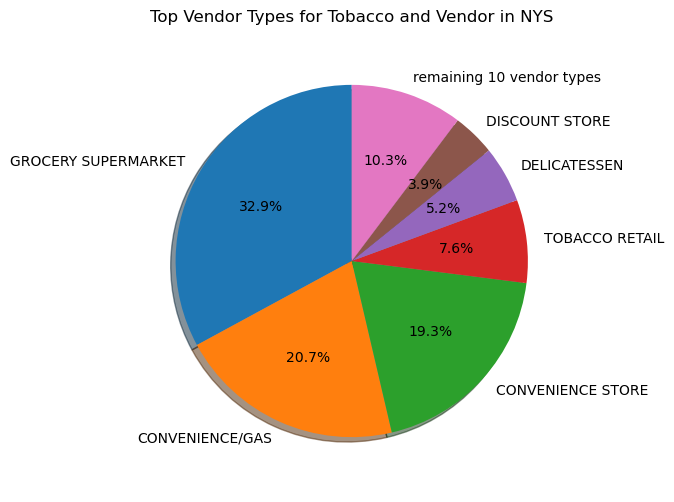

```python
temp = df['VENDOR TYPE'].value_counts()
temp2 = temp.head(6)
if len(temp) > 6:
    temp2['remaining {0} vendor types'.format(len(temp) - 6)] = sum(temp[6:])
temp2.plot(kind='pie',
           figsize=(5, 6),
           autopct='%1.1f%%', # add in percentages
           startangle=90,     # start angle 90°
           shadow=True,       # add shadow
          )

plt.title('Top Vendor Types for Tobacco and Vendor in NYS')
plt.axis('equal') # Sets the pie chart to look like a circle.
plt.ylabel(None)  # Remove y axis label

plt.show()
```

```python
df_topops = df.groupby(['OPERATION NAME']).size().reset_index(name='count')
df_topops = df_topops.sort_values(by="count", ascending=False)
df_topops = df_topops.query('count > 15')
df_topops
```

|  | OPERATION NAME | count |
| --- | --- | --- |
| 2868 | BP | 79 |
| 4556 | DOLLAR GENERAL | 59 |
| 9607 | MOBIL | 58 |
| 13633 | SUNOCO | 48 |
| 12290 | SHELL | 39 |
| 2834 | BOLLA OPERATING CORP. | 35 |
| 5622 | FAMILY DOLLAR | 33 |
| 1006 | 7-ELEVEN | 33 |
| 12852 | SPEEDWAY | 31 |
| 14608 | VALERO | 27 |
| 13028 | SPEEDWAY LLC | 25 |
| 4056 | CROSBY'S | 23 |
| 3181 | BYRNE DAIRY | 22 |
| 13456 | STEWARTS | 21 |
| 12680 | SMOKER'S CHOICE | 20 |
| 6703 | GULF | 19 |
| 4553 | DOLGEN NEW YORK, LLC | 18 |
| 8170 | KWIK FILL | 17 |
| 5528 | EXXON | 17 |
| 10526 | OK PETROLEUM | 16 |
| 11307 | QUICK LEES | 16 |
| 3615 | CITGO | 16 |
| 3874 | CONSUMERS BEVERAGES | 16 |

### GRAPH #2: BAR CHART

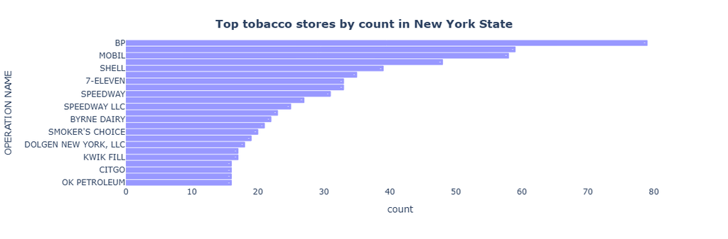

```python
fig = px.bar(df_topops, x="count", y="OPERATION NAME", barmode = 'stack',
      text_auto = True)

fig.update_layout(
    plot_bgcolor="white",
    # Ensure the correct sorting
    yaxis={'categoryorder':'total ascending'},
)

fig.update_traces(marker_color='blue', marker_line_color='blue',
                  marker_line_width=1, opacity=0.4)

fig.update_layout(
    title={
        'text': '<b>Top tobacco stores by count in New York State</b>',
        'x':0.5,
        'xanchor': 'center',
        'yanchor': 'top'
    }
)

fig.show()
```

### GRAPH #3: HISTOGRAM

With the missing zip codes filled in previously, we will create a basic histogram of the ZIP code spread of the stores

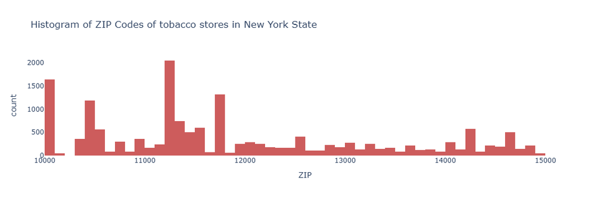

```python
fig = px.histogram(data_frame = df,
             x = 'ZIP',
             title='Histogram of ZIP Codes of tobacco stores in New York State',
             color_discrete_sequence=['indianred'] # color of histogram bar
            )

fig.update_layout(
    showlegend=False,
    plot_bgcolor="white",
)

fig.update_layout(
    xaxis = dict(
        showexponent = 'none' # get rid of the 'k' in the '11k', '12k' in the x-axes
    )
)

fig.update_layout(xaxis_tickformat="5") # force the x-axes to show 10000, 11000, etc. like real zip codes!

fig.show()
```

### FURTHER TRANSFORMATIONS AND GRAPHS

Add the 'County' to the county name as a new field (for later merge purposes)

```python
df['COUNTY_NAME'] = df['COUNTY'].str.title() + " County"
df
```

|  | LOCAL HEALTH UNIT | OPERATION NAME | ADDRESS | CITY | STATE | MUNICIPALITY | COUNTY | VENDOR TYPE | CREATION DATE | LOCATION | LATITUDE | LONGITUDE | ZIP | COUNTY_NAME |
| --- | --- | --- | --- | --- | --- | --- | --- | --- | --- | --- | --- | --- | --- | --- |
| 0 | CLINTON | GRAND UNION | 2 GORMAN WAY | PERU | NY | PERU | CLINTON | GROCERY SUPERMARKET | 07/10/2023 | 2 GORMAN WAY PERU, NY 12972 (44.577028232, -73... | 44.577028232 | -73.525724408 | 12972 | Clinton County |
| 1 | DUTCHESS | CHESTNUT MARTS | 3997 ROUTE 22 | WASSAIC | NY | AMENIA | DUTCHESS | CONVENIENCE/GAS | 07/10/2023 | 3997 ROUTE 22 WASSAIC, NY 12592 (41.790814801,... | 41.790814801 | -73.553360632 | 12592 | Dutchess County |
| 2 | NYC | 2918 GAS CORP | 2918 BOSTON ROAD | BRONX | NY | BRONX | NEW YORK | OTHER | 07/10/2023 | 2918 BOSTON ROAD BRONX, NY 10469 (40.868058834... | 40.868058834 | -73.858776062 | 10469 | New York County |
| 3 | NYC | MAHANT 385 INC | 385 CANAL STREET | NEW YORK | NY | MANHATTAN | NEW YORK | TOBACCO RETAIL | 07/10/2023 | 385 CANAL STREET NEW YORK, NY 10013 (40.721667... | 40.721667889 | -74.004767693 | 10013 | New York County |
| 4 | NYC | SHISHA KING CORP | 656 SUTTER AVENUE | BROOKLYN | NY | BROOKLYN | NEW YORK | GROCERY SUPERMARKET | 07/10/2023 | 656 SUTTER AVENUE BROOKLYN, NY 11207 (40.66938... | 40.669383086 | -73.894472157 | 11207 | New York County |
| ... | ... | ... | ... | ... | ... | ... | ... | ... | ... | ... | ... | ... | ... | ... |
| 16754 | CHAUTAUQUA | MATT'S NEWS | 93 EAST THIRD STREET | DUNKIRK | NY | DUNKIRK | CHAUTAUQUA | CONVENIENCE STORE | 07/10/2023 | 93 EAST THIRD STREET DUNKIRK, NY 14048 (42.485... | 42.485506391 | -79.329351149 | 14048 | Chautauqua County |
| 16755 | NYC | EASTSIDE CONVENIENCE CORPORATION | 1726 1ST AVENUE | NEW YORK | NY | MANHATTAN | NEW YORK | CONVENIENCE STORE | 07/10/2023 | 1726 1ST AVENUE NEW YORK, NY 10128 (40.779000... | 40.779000651 | -73.947582326 | 10128 | New York County |
| 16756 | NYC | DOPEBOYS EXOTIC INC | 1437 FLATBUSH AVENUE | BROOKLYN | NY | BROOKLYN | NEW YORK | GROCERY SUPERMARKET | 07/10/2023 | 1437 FLATBUSH AVENUE BROOKLYN, NY 11210 (40.63... | 40.635653511 | -73.950397388 | 11210 | New York County |
| 16757 | GLENS FALLS DO | STEWART'S SHOP #215 | 107 BROADWAY | FORT EDWARD | NY | FORT EDWARD | WASHINGTON | CONVENIENCE STORE | 07/10/2023 | 107 BROADWAY FORT EDWARD, NY 12828 (43.2672095... | 43.26720959700003 | -73.58553800399994 | 12828 | Washington County |
| 16758 | NYC | A & S ROCKAWAY DELI GROCERY CORP. | 123-36 ROCKAWAY BOULEVARD | SOUTH OZONE PARK | NY | QUEENS | NEW YORK | GROCERY SUPERMARKET | 07/10/2023 | 123-36 ROCKAWAY BOULEVARD SOUTH OZONE PARK, NY... | 40.67530578 | -73.813723332 | 11420 | New York County |

16759 rows × 14 columns

Create a new dataframe df_counties; isolating the county name created in the previous step with the count in the df dataframe.

This will be used in the next section.

```python
df_counties = df.groupby(['COUNTY_NAME']).size().reset_index(name='count')
df_counties.rename(columns = {'COUNTY_NAME': 'County'}, inplace = True)
df_counties.rename(columns = {"count": "Stores by County"}, inplace = True)
df_counties
```

|  | County | Stores by County |
| --- | --- | --- |
| 0 | Albany County | 295 |
| 1 | Allegany County | 48 |
| 2 | Broome County | 183 |
| 3 | Cattaraugus County | 49 |
| 4 | Cayuga County | 53 |
| 5 | Chautauqua County | 106 |
| 6 | Chemung County | 86 |
| 7 | Chenango County | 49 |
| 8 | Clinton County | 90 |
| 9 | Columbia County | 69 |
| 10 | Cortland County | 42 |
| 11 | Delaware County | 58 |
| 12 | Dutchess County | 282 |
| 13 | Erie County | 804 |
| 14 | Essex County | 47 |
| 15 | Franklin County | 47 |
| 16 | Fulton County | 55 |
| 17 | Genesee County | 54 |
| 18 | Greene County | 60 |
| 19 | Hamilton County | 9 |
| 20 | Herkimer County | 62 |
| 21 | Jefferson County | 107 |
| 22 | Lewis County | 24 |
| 23 | Livingston County | 64 |
| 24 | Madison County | 54 |
| 25 | Monroe County | 621 |
| 26 | Montgomery County | 55 |
| 27 | Nassau County | 1038 |
| 28 | New York County | 6848 |
| 29 | Niagara County | 173 |
| 30 | Oneida County | 222 |
| 31 | Onondaga County | 406 |
| 32 | Ontario County | 84 |
| 33 | Orange County | 298 |
| 34 | Orleans County | 28 |
| 35 | Oswego County | 103 |
| 36 | Otsego County | 66 |
| 37 | Putnam County | 92 |
| 38 | Rensselaer County | 156 |
| 39 | Rockland County | 204 |
| 40 | Saratoga County | 167 |
| 41 | Schenectady County | 173 |
| 42 | Schoharie County | 31 |
| 43 | Schuyler County | 16 |
| 44 | Seneca County | 33 |
| 45 | St. Lawrence County | 104 |
| 46 | Steuben County | 91 |
| 47 | Suffolk County | 1377 |
| 48 | Sullivan County | 91 |
| 49 | Syracuse County | 1 |
| 50 | Tioga County | 37 |
| 51 | Tompkins County | 55 |
| 52 | Ulster County | 166 |
| 53 | Warren County | 93 |
| 54 | Washington County | 49 |
| 55 | Wayne County | 80 |
| 56 | Westchester County | 949 |
| 57 | Wyoming County | 35 |
| 58 | Yates County | 20 |

### GRAPH #4: CHOROPLETH MAP

To do a choropleth map, we first need to get the NY FIPS values from an outside source.

We can use the US Census site here

https://www2.census.gov/geo/docs/reference/codes2020/place_by_cou/st36_ny_place_by_county2020.txt

The following code assigns this url to a variable for the NY FIPS CSC (delimited by '|') then puts into a local dataframe df_temp

```python
url="https://www2.census.gov/geo/docs/reference/codes2020/place_by_cou/st36_ny_place_by_county2020.txt"

df_temp =pd.read_csv(url, sep='|', dtype=str)
print(df_temp)
```

```
     STATE STATEFP COUNTYFP     COUNTYNAME PLACEFP   PLACENS  \
0       NY      36      001  Albany County   01000  00978659
1       NY      36      001  Albany County   01517  02391511
2       NY      36      001  Albany County   16749  00978847
3       NY      36      001  Albany County   17332  02391620
4       NY      36      001  Albany County   30521  02390869
...    ...     ...      ...            ...     ...       ...
1307    NY      36      123   Yates County   20896  02391645
1308    NY      36      123   Yates County   21050  02391647
1309    NY      36      123   Yates County   39463  02631232
1310    NY      36      123   Yates County   57177  02391057
1311    NY      36      123   Yates County   64199  02391105

                 PLACENAME                     TYPE CLASSFP FUNCSTAT
0              Albany city       INCORPORATED PLACE      C5        A
1         Altamont village       INCORPORATED PLACE      C1        A
2              Cohoes city       INCORPORATED PLACE      C5        A
3          Colonie village       INCORPORATED PLACE      C1        A
4     Green Island village       INCORPORATED PLACE      C1        A
...                    ...                      ...     ...      ...
1307       Dresden village       INCORPORATED PLACE      C1        A
1308        Dundee village       INCORPORATED PLACE      C1        A
1309        Keuka Park CDP  CENSUS DESIGNATED PLACE      U1        S
1310      Penn Yan village       INCORPORATED PLACE      C1        A
1311     Rushville village       INCORPORATED PLACE      C1        A

[1312 rows x 10 columns]
```

Isolate just the fields we need from the FIPS (df_temp) dataframe - state, county, FIPS

Then drop the duplicates from the dataframe so we have the ~62 rows to match the number of counties in the NY state

```python
df_ny_fips = df_temp[['STATEFP','COUNTYFP','COUNTYNAME']].copy()
df_ny_fips['FIPS'] = df_ny_fips['STATEFP'] + df_ny_fips['COUNTYFP']
df_ny_fips[['FIPS']] = df_ny_fips[['FIPS']].astype('string')
df_ny_fips=df_ny_fips.drop_duplicates()
df_ny_fips
```

|  | STATEFP | COUNTYFP | COUNTYNAME | FIPS |
| --- | --- | --- | --- | --- |
| 0 | 36 | 001 | Albany County | 36001 |
| 15 | 36 | 003 | Allegany County | 36003 |
| 32 | 36 | 005 | Bronx County | 36005 |
| 33 | 36 | 007 | Broome County | 36007 |
| 45 | 36 | 009 | Cattaraugus County | 36009 |
| ... | ... | ... | ... | ... |
| 1213 | 36 | 115 | Washington County | 36115 |
| 1223 | 36 | 117 | Wayne County | 36117 |
| 1240 | 36 | 119 | Westchester County | 36119 |
| 1296 | 36 | 121 | Wyoming County | 36121 |
| 1307 | 36 | 123 | Yates County | 36123 |

62 rows × 4 columns

Merge the df_counties with the df_temp (the FIPS) on the County_name value so the df_counties dataframe has the FIPS values to do a choropleth map

```python
#print(df_counties.merge(df_ny_fips, left_on='COUNTY_NAME', right_on='COUNTYNAME'))
df_counties=df_counties.merge(df_ny_fips, left_on='County', right_on='COUNTYNAME')
df_counties
```

|  | County | Stores by County | STATEFP | COUNTYFP | COUNTYNAME | FIPS |
| --- | --- | --- | --- | --- | --- | --- |
| 0 | Albany County | 295 | 36 | 001 | Albany County | 36001 |
| 1 | Allegany County | 48 | 36 | 003 | Allegany County | 36003 |
| 2 | Broome County | 183 | 36 | 007 | Broome County | 36007 |
| 3 | Cattaraugus County | 49 | 36 | 009 | Cattaraugus County | 36009 |
| 4 | Cayuga County | 53 | 36 | 011 | Cayuga County | 36011 |
| 5 | Chautauqua County | 106 | 36 | 013 | Chautauqua County | 36013 |
| 6 | Chemung County | 86 | 36 | 015 | Chemung County | 36015 |
| 7 | Chenango County | 49 | 36 | 017 | Chenango County | 36017 |
| 8 | Clinton County | 90 | 36 | 019 | Clinton County | 36019 |
| 9 | Columbia County | 69 | 36 | 021 | Columbia County | 36021 |
| 10 | Cortland County | 42 | 36 | 023 | Cortland County | 36023 |
| 11 | Delaware County | 58 | 36 | 025 | Delaware County | 36025 |
| 12 | Dutchess County | 282 | 36 | 027 | Dutchess County | 36027 |
| 13 | Erie County | 804 | 36 | 029 | Erie County | 36029 |
| 14 | Essex County | 47 | 36 | 031 | Essex County | 36031 |
| 15 | Franklin County | 47 | 36 | 033 | Franklin County | 36033 |
| 16 | Fulton County | 55 | 36 | 035 | Fulton County | 36035 |
| 17 | Genesee County | 54 | 36 | 037 | Genesee County | 36037 |
| 18 | Greene County | 60 | 36 | 039 | Greene County | 36039 |
| 19 | Hamilton County | 9 | 36 | 041 | Hamilton County | 36041 |
| 20 | Herkimer County | 62 | 36 | 043 | Herkimer County | 36043 |
| 21 | Jefferson County | 107 | 36 | 045 | Jefferson County | 36045 |
| 22 | Lewis County | 24 | 36 | 049 | Lewis County | 36049 |
| 23 | Livingston County | 64 | 36 | 051 | Livingston County | 36051 |
| 24 | Madison County | 54 | 36 | 053 | Madison County | 36053 |
| 25 | Monroe County | 621 | 36 | 055 | Monroe County | 36055 |
| 26 | Montgomery County | 55 | 36 | 057 | Montgomery County | 36057 |
| 27 | Nassau County | 1038 | 36 | 059 | Nassau County | 36059 |
| 28 | New York County | 6848 | 36 | 061 | New York County | 36061 |
| 29 | Niagara County | 173 | 36 | 063 | Niagara County | 36063 |
| 30 | Oneida County | 222 | 36 | 065 | Oneida County | 36065 |
| 31 | Onondaga County | 406 | 36 | 067 | Onondaga County | 36067 |
| 32 | Ontario County | 84 | 36 | 069 | Ontario County | 36069 |
| 33 | Orange County | 298 | 36 | 071 | Orange County | 36071 |
| 34 | Orleans County | 28 | 36 | 073 | Orleans County | 36073 |
| 35 | Oswego County | 103 | 36 | 075 | Oswego County | 36075 |
| 36 | Otsego County | 66 | 36 | 077 | Otsego County | 36077 |
| 37 | Putnam County | 92 | 36 | 079 | Putnam County | 36079 |
| 38 | Rensselaer County | 156 | 36 | 083 | Rensselaer County | 36083 |
| 39 | Rockland County | 204 | 36 | 087 | Rockland County | 36087 |
| 40 | Saratoga County | 167 | 36 | 091 | Saratoga County | 36091 |
| 41 | Schenectady County | 173 | 36 | 093 | Schenectady County | 36093 |
| 42 | Schoharie County | 31 | 36 | 095 | Schoharie County | 36095 |
| 43 | Schuyler County | 16 | 36 | 097 | Schuyler County | 36097 |
| 44 | Seneca County | 33 | 36 | 099 | Seneca County | 36099 |
| 45 | St. Lawrence County | 104 | 36 | 089 | St. Lawrence County | 36089 |
| 46 | Steuben County | 91 | 36 | 101 | Steuben County | 36101 |
| 47 | Suffolk County | 1377 | 36 | 103 | Suffolk County | 36103 |
| 48 | Sullivan County | 91 | 36 | 105 | Sullivan County | 36105 |
| 49 | Tioga County | 37 | 36 | 107 | Tioga County | 36107 |
| 50 | Tompkins County | 55 | 36 | 109 | Tompkins County | 36109 |
| 51 | Ulster County | 166 | 36 | 111 | Ulster County | 36111 |
| 52 | Warren County | 93 | 36 | 113 | Warren County | 36113 |
| 53 | Washington County | 49 | 36 | 115 | Washington County | 36115 |
| 54 | Wayne County | 80 | 36 | 117 | Wayne County | 36117 |
| 55 | Westchester County | 949 | 36 | 119 | Westchester County | 36119 |
| 56 | Wyoming County | 35 | 36 | 121 | Wyoming County | 36121 |
| 57 | Yates County | 20 | 36 | 123 | Yates County | 36123 |

Create choropleth map

The JSON data will be retrieved from another master dataset -

https://raw.githubusercontent.com/plotly/datasets/master/geojson-counties-fips.json

In addition, we will use the 'from urllib.request import urlopen' and 'with' statement to get the connection for the json

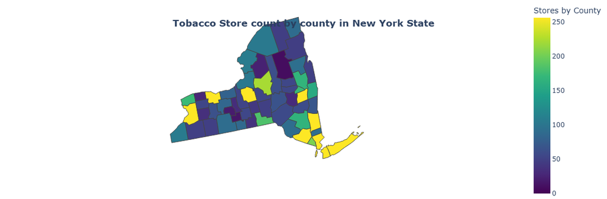

```python
import json

from urllib.request import urlopen

with urlopen('https://raw.githubusercontent.com/plotly/datasets/master/geojson-counties-fips.json') as response:
    counties = json.load(response)

fig = px.choropleth(df_counties, geojson=counties, locations="FIPS", color="Stores by County",
                    color_continuous_scale='Viridis',
                    range_color=(0, 256),
                    scope='usa',
                    hover_name = 'County',
                    labels={'count': 'store count'}
                    )

fig.update_layout(
    title={
        'text': '<b>Tobacco Store count by county in New York State</b>',
        'y':0.9,
        'x':0.5,
        'xanchor': 'center',
        'yanchor': 'top'
    }
)

fig.update_geos(fitbounds='locations', visible=False) # use this to isolate the state!!!
fig.update_layout(margin={'r': 0, 't': 0, 'l': 0, 'b': 0})
fig.show()
```

### NOTES / REMARKS

1. Looking at the analysis queries, the most populous regions / areas are the ones with the most stores. It would take a deeper dive using the external census datasets to see if there is a direct match from the most populous cities to the highest number of stores.
2. There is an unknown factor - are native tribe owned stores counted in the dataset? This would take a manual look through the dataset to see if such sites are listed. If not, that is a considerable source of sales which is missing.